# Nextflow (& some other workflow systems)

Rad Suchecki

Monday, 25 June, 2018

https://xkcd.com/242/

### Let others (and yourself!)

- reliably re-run your analyses
- trace back origins of results
- triggers
  - new data (e.g. additional samples)
  - updated software
  - different compute environment (cloud?)
  - errors found
  - new ideas

### A workflow management system might help…

### Aims & considerations

- turn-key reproducibility
- re-usability

[figure not shown]

### Workflow systems

- [214 systems and counting](https://s.apache.org/existing-workflow-systems)
  - from `make` to Galaxy
  - see also [this list](https://github.com/pditommaso/awesome-pipeline)
- active development?
- (community) support?
- flexibility and ease of development
- learning curve?
- abstraction level - just right ;-)
- …

### Non-GUI, bioinf-flavoured and… lively

- Snakemake: *a pythonic workflow system*
  - follows `make` philosophy
  - rules and patterns that depend on input/output file names
  - explicit, precomputed DAG
- Nextflow
  - dataflow programming model - think Unix pipes
  - conditional paths which may depend on intermediate results
  - DAG not known in advance
- Comparisons
  - 2018 https://vatlab.github.io/blog/post/comparison/ (by SoS authors)
  - 2017 https://www.nature.com/articles/nbt.3820/tables/1 (by NF authors)
  - 2016 https://jmazz.me/blog/NGS-Workflows (blog)
  - 2016 https://doi.org/10.1093/bib/bbw020 (review, not quite right about NF)

## [Nextflow](https://www.nextflow.io/)

- Designed for
  - specific use case: seamless scalability of existing tools and scripts
  - for bioinformaticians familiar with programming

### Features

- Separation of pipeline logic from compute environment definition(s)
- Syntax is a superset of Groovy, but **polyglot**
  - easily mix scripting languages
- Multiple *executors*
  - SGE, LSF, **SLURM**, PBS/Torque, NQSII HTCondor, Ignite, Kubernets, AWS Batch
- NEW! Support for Conda/[Bioconda](https://bioconda.github.io/)

https://www.nature.com/articles/nbt.3820/

## More about Nextflow

### *Processes* (tasks) executed in separate work directories

- safe and lock-free parallelization
- easy clean-up, no issue of partial results following an error

### *Channels*

- facilitate data flow between processes

## Getting started

### Required

- POSIX compatible system (Linux, Solaris, OS X, etc)
- Java 8

### Install

```
curl -s https://get.nextflow.io | bash
```

### Software you want to run

- Available on PATH or under `bin/`
- via Docker
- via Singularity
- via Conda
- via Modules

## Hello world syntax

```bash
curl -sL  https://raw.githubusercontent.com/nextflow-io/hello/master/main.nf
```

```
#!/usr/bin/env nextflow
echo true

cheers = Channel.from 'Bonjour', 'Ciao', 'Hello', 'Hola'

process sayHello {
  input:
    val x from cheers
  script:
    """
    echo '$x world!'
    """
}
```

## [Hello world shared pipelines](https://www.nextflow.io/blog/2014/share-nextflow-pipelines-with-github.html)

```bash
nextflow run hello
```

```
N E X T F L O W  ~  version 0.30.1
Pulling nextflow-io/hello ...
 downloaded from https://github.com/nextflow-io/hello.git
Launching `nextflow-io/hello` [friendly_roentgen] - revision: c9b0ec7286 [master]
[warm up] executor > local
[5c/104ae2] Submitted process > sayHello (2)
[d7/11b28c] Submitted process > sayHello (1)
[4e/e5e39c] Submitted process > sayHello (3)
Ciao world!
Bonjour world!
[15/9f213a] Submitted process > sayHello (4)
Hello world!
Hola world!
```

```bash
nextflow info hello
```

```
 project name: nextflow-io/hello
 repository  : https://github.com/nextflow-io/hello
 local path  : /home/rad/.nextflow/assets/nextflow-io/hello
 main script : main.nf
 revisions   :
 * master (default)
   mybranch
   v1.1 [t]
   v1.2 [t]
```

## Run specific revision (tag/branch/commit SHA hash)

```bash
nextflow run hello -r v1.1
```

```bash
nextflow run hello -r mybranch
```

```bash
nextflow run hello -r 451ebd9
```

```
N E X T F L O W  ~  version 0.30.1
Launching `nextflow-io/hello` [confident_kalam] - revision: 451ebd9dcb56045d80963945305811aa65f413d0
[warm up] executor > local
[e0/bbb32c] Submitted process > sayHello (2)
[c0/c7c8ef] Submitted process > sayHello (1)
[f9/e08c9a] Submitted process > sayHello (3)
Bojour world!
Ciao world!
[9a/195a35] Submitted process > sayHello (4)
Hello world!
Hola world!
```

## Something a bit more useful

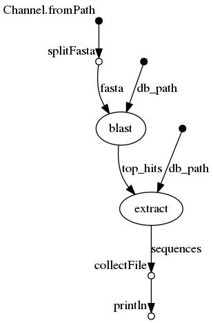

```bash
nextflow run blast-example -with-docker -with-dag doc/blast.png
```

```
N E X T F L O W  ~  version 0.30.1
Launching `nextflow-io/blast-example` [furious_lovelace] - revision: 34a29e1cdc [master]
[warm up] executor > local
[5b/2f03b9] Submitted process > blast (1)
[de/c4a679] Submitted process > extract (1)
matching sequences:
 >lcl|1ABO:B unnamed protein product
MNDPNLFVALYDFVASGDNTLSITKGEKLRVLGYNHNGEWCEAQTKNGQGWVPSNYITPVNS
>lcl|1ABO:A unnamed protein product
MNDPNLFVALYDFVASGDNTLSITKGEKLRVLGYNHNGEWCEAQTKNGQGWVPSNYITPVNS
>lcl|1YCS:B unnamed protein product
PEITGQVSLPPGKRTNLRKTGSERIAHGMRVKFNPLPLALLLDSSLEGEFDLVQRIIYEVDDPSLPNDEGITALHNAVCA
GHTEIVKFLVQFGVNVNAADSDGWTPLHCAASCNNVQVCKFLVESGAAVFAMTYSDMQTAADKCEEMEEGYTQCSQFLYG
VQEKMGIMNKGVIYALWDYEPQNDDELPMKEGDCMTIIHREDEDEIEWWWARLNDKEGYVPRNLLGLYPRIKPRQRSLA
>lcl|1IHD:C unnamed protein product
LPNITILATGGTIAGGGDSATKSNYTVGKVGVENLVNAVPQLKDIANVKGEQVVNIGSQDMNDNVWLTLAKKINTDCDKT
```

## Compute profiles

- Implemented/tested with my pipelines
  - `standard` (i.e. local/interactive assuming all software available)
  - `slurm`
  - `modules`
  - `docker`
  - `singularity`
  - `ec2` (including auto-scaling)
  - `conda` (missing a bioconda recipe for biokanga)

```bash
# some of the profiles can, and others are intended to be used in concert, e.g.
nextflow run csiro-crop-informatics/reproducible_poc -r develop -profile slurm,modules
# or
nextflow run csiro-crop-informatics/reproducible_poc -r develop -profile slurm,singularity,singularitymodule
```

- Next: `k8s`, `awsbatch`, …

## Modules

- Required modules are defined separately for each process (`withName`) or for multiple processes (`withLabel`)

```bash
curl -sL https://raw.githubusercontent.com/csiro-crop-informatics/reproducible_poc/develop/conf/modules.config
```

```
process {
    withName: fastQC {
      module = 'fastqc/0.11.5'
    }
    withName: multiQC {
      module = 'python/2.7.13'
    }
    withName: hisat2Index {
      module = 'hisat/2.0.5'
    }
    withName: hisat2Align {
      module = ['hisat/2.0.5','samtools/1.7.0']
    }
    withLabel: biokanga {
      module = 'biokanga/4.3.9'
    }

    withLabel: samtools {
      module = 'samtools/1.7.0'
    }
}
```

- Note! These are compute environment specific

## Containers

- Required containers are defined separately for each process (`withName`) or for multiple processes (`withLabel`)
- Available on docker hub
  - Used both by `docker` and `singularity`

```bash
curl -sL https://raw.githubusercontent.com/csiro-crop-informatics/reproducible_poc/develop/conf/containers.config
```

```
process {
    withName: extractStatsFromBAMs {
      container = 'genomicpariscentre/samtools:1.4.1'
    }
    withName: fastQC {
      container = 'genomicpariscentre/fastqc:0.11.5'
    }
    withName: multiQC {
      container = 'ewels/multiqc:v1.5'
    }
    withName: fasta2mockFASTQ {
      container = 'rsuchecki/pigz:2.3.4'
    }
    withLabel: biokanga {
      container = 'rsuchecki/biokanga:4.3.9'
    }
    withLabel: hisat2 {
      container = 'cyverse/hisat2:2.0.5'
    }
}
```

### Workflow introspection

- Nextflow offers detailed
  - execution [reports](https://rsuchecki.github.io/reproducible/report.html)
  - execution [timelines](https://rsuchecki.github.io/reproducible/timeline.html)

### NF Resources

- https://www.nextflow.io/
- https://github.com/nextflow-io/patterns

### Future?

- http://nf-co.re/
- https://github.com/assemblerflow/flowcraft (Or a step too far?)

## According to Nextflow authors

- *The dataflow model is superior to alternative solutions based on a Make-like approach, such as Snakemake, in which computation involves the pre-estimation of all computational dependencies, starting from the expected results up until the input raw data. A Make-like procedure requires a directed acyclic graph (DAG), whose storage requirement is a limiting factor for very large computations. In contrast, as the top to bottom processing model used by Nextflow follows the natural flow of data analysis, it does not require a DAG. Instead, the graph it traverses is merely incidental and does not need to be pre-computed or even stored, thereby ensuring high scalability.*

# This slide is intentionally left blank

## [Pipeline](https://github.com/csiro-crop-informatics/reproducible_poc) run (I)

```bash
nextflow run csiro-crop-informatics/reproducible_poc -r develop -profile singularity -with-dag doc/flowchart.dot
```

```
N E X T F L O W  ~  version 0.30.1
Launching `csiro-crop-informatics/reproducible_poc` [infallible_brattain] - revision: e957f4b275 [develop]
NOTE: Your local project version looks outdated - a different revision is available in the remote repository [5b495fe02f]
[warm up] executor > local
[12/5181e6] Submitted process > fetchRef (A_thaliana)
[c2/8d5f02] Submitted process > fetchReads
[ba/6e35da] Submitted process > hisat2Index (A_thaliana)
[da/71e1b9] Submitted process > kangaIndex (A_thaliana)
[e6/2bf4e9] Submitted process > fastQC ([name:real, nreads:10k, seqerr:unk, rep:na, format:fq])
[29/8e7364] Submitted process > hisat2Align ([name:real, nreads:10k, seqerr:unk, rep:na, format:fq, ref:A_thaliana, aligner:HISAT2])
[4e/aa282b] Submitted process > kangaAlign ([name:real, nreads:10k, seqerr:unk, rep:na, format:fq, ref:A_thaliana, aligner:BioKanga])
[99/cf76dd] Submitted process > extractStatsFromBAMs ([name:real, nreads:10k, seqerr:unk, rep:na, format:fq, ref:A_thaliana, aligner:HISAT2])
[27/a34b7f] Submitted process > multiQC
[24/858f7b] Submitted process > extractStatsFromBAMs ([name:real, nreads:10k, seqerr:unk, rep:na, format:fq, ref:A_thaliana, aligner:BioKanga])
[6b/c066be] Submitted process > combineStats
[23/3808f0] Submitted process > MOCK_generateFigures
[8a/610d6c] Submitted process > MOCK_generateReportMatter
```

## [Pipeline](https://github.com/csiro-crop-informatics/reproducible_poc) run (II)

```bash
nextflow run csiro-crop-informatics/reproducible_poc -r develop -resume -profile singularity --nsimreads 10000
```

```
N E X T F L O W  ~  version 0.30.1
Launching `csiro-crop-informatics/reproducible_poc` [friendly_shockley] - revision: e957f4b275 [develop]
NOTE: Your local project version looks outdated - a different revision is available in the remote repository [5b495fe02f]
[warm up] executor > local
[12/5181e6] Cached process > fetchRef (A_thaliana)
[c2/8d5f02] Cached process > fetchReads
[e6/2bf4e9] Cached process > fastQC ([name:real, nreads:10k, seqerr:unk, rep:na, format:fq])
[ba/6e35da] Cached process > hisat2Index (A_thaliana)
[da/71e1b9] Cached process > kangaIndex (A_thaliana)
[29/8e7364] Cached process > hisat2Align ([name:real, nreads:10k, seqerr:unk, rep:na, format:fq, ref:A_thaliana, aligner:HISAT2])
[4e/aa282b] Cached process > kangaAlign ([name:real, nreads:10k, seqerr:unk, rep:na, format:fq, ref:A_thaliana, aligner:BioKanga])
[24/858f7b] Cached process > extractStatsFromBAMs ([name:real, nreads:10k, seqerr:unk, rep:na, format:fq, ref:A_thaliana, aligner:BioKanga])
[99/cf76dd] Cached process > extractStatsFromBAMs ([name:real, nreads:10k, seqerr:unk, rep:na, format:fq, ref:A_thaliana, aligner:HISAT2])
[05/5649ae] Submitted process > kangaSimReads ([name:A_thaliana, nreads:10000, seqerr:1.5, rep:1, format:fa])
[10/3aebcc] Submitted process > fasta2mockFASTQ ([name:A_thaliana, nreads:10000, seqerr:1.5, rep:1, format:fa])
[a0/ce8767] Submitted process > kangaAlign ([name:A_thaliana, nreads:10000, seqerr:1.5, rep:1, format:fa, ref:A_thaliana, aligner:BioKanga])
[71/62e3f7] Submitted process > hisat2Align ([name:A_thaliana, nreads:10000, seqerr:1.5, rep:1, format:fa, ref:A_thaliana, aligner:HISAT2])
[71/5b1259] Submitted process > fastQC ([name:A_thaliana, nreads:10000, seqerr:1.5, rep:1, format:fa])
[26/2bb088] Submitted process > extractStatsFromBAMs ([name:A_thaliana, nreads:10000, seqerr:1.5, rep:1, format:fa, ref:A_thaliana, aligner:BioKanga])
[1e/0f0bc9] Submitted process > extractStatsFromBAMs ([name:A_thaliana, nreads:10000, seqerr:1.5, rep:1, format:fa, ref:A_thaliana, aligner:HISAT2])
[0a/946feb] Submitted process > combineStats
[70/d0b8ad] Submitted process > MOCK_generateFigures
[36/4f3c57] Submitted process > multiQC
[e0/491389] Submitted process > MOCK_generateReportMatter
```

## Pipeline flow

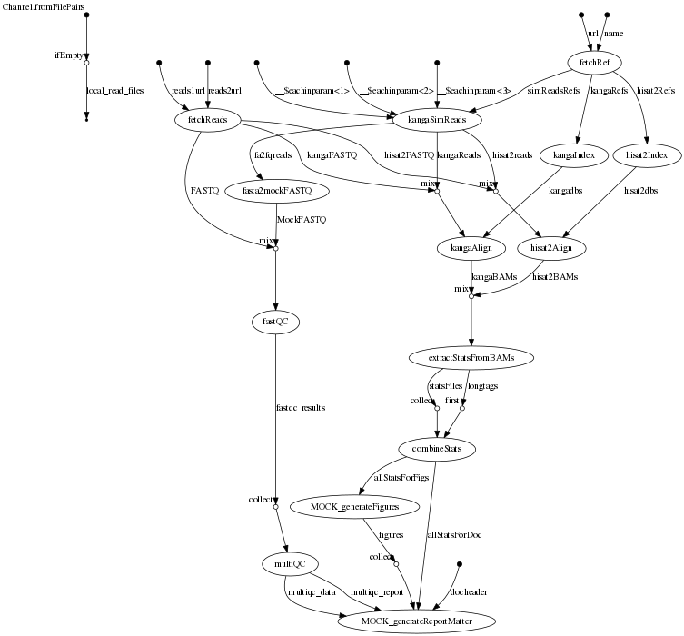

## Pipeline syntax

- Primarily definitions of *processes*, each with well defined input and output values and/or files, usually passed through *channels*

```bash
curl -sL https://raw.githubusercontent.com/csiro-crop-informatics/reproducible_poc/develop/main.nf
```

```
//READ SIMULATION PARAMS
seqerrs = params.seqerrs.toString().tokenize(",")
nsimreadsarr = params.nsimreads.toString().tokenize(",")*.toInteger()
nrepeat = params.nrepeat
//INPUT GENOME PARAMS
url = params.url
name = params.name
//INPUT READS PARAMS
reads1url = params.realreads1
reads2url = params.realreads2

docheader = file(params.docheader)

def helpMessage() {
    log.info"""
    ===========================================================
    csiro-crop-informatics/reproducible_poc  ~  version ${params.version}
    ===========================================================
    Usage:

    nextflow run csiro-crop-informatics/reproducible_poc -r develop

    Default params:
    seqerrs     : ${params.seqerrs}
    nsimreads   : ${params.nsimreads} - this can be a comma-delimited list e.g. 100,20000,400
    nrepeat     : ${params.nrepeat}
    url         : ${params.url}
    name        : ${params.name}
    outdir      : ${params.outdir}
    publishmode : ${params.publishmode} use copy or move if working across filesystems
    """.stripIndent()
}

// Show help message
params.help = false
if (params.help){
    helpMessage()
    exit 0
}

/*
 * Create a channel for (local) input read files
 */
//Channel
//    .fromFilePairs( params.reads, size: 2 )
//    .ifEmpty { exit 1, "Cannot find reads matching: ${params.reads}\nNB: Path must contain at least one * wildcard and be enclosed in quotes." }
//    .set { local_read_files }

process fetchRef {
  tag {name}
  input:
    val url
    val name

  output:
    set val(name), file(ref) into kangaRefs, hisat2Refs, simReadsRefs

  script:
    """
    curl ${url} | gunzip --stdout | head -100000 > ref
    """
}


process fetchReads {

  input:
    val reads1url
    val reads2url

  output:
    set val(longtag), val(nametag),file("r1.gz"), file("r2.gz") into FASTQ, hisat2FASTQ, kangaFASTQ

  script:
    nametag = "tmpTAG"
    longtag = ["name":"real", "nreads":"10k", "seqerr":"unk", "rep":"na", "format":"fq"]
    """
    curl ${reads1url} | gunzip --stdout | head -n 40000 | pigz --fast > r1.gz
    curl ${reads2url} | gunzip --stdout | head -n 40000 | pigz --fast > r2.gz
    """

}

process kangaSimReads {
  label 'biokanga'
  tag {longtag}
  input:
    set val(name), file(ref) from simReadsRefs
    each nsimreads from nsimreadsarr
    each seqerr from seqerrs
    each rep from 1..nrepeat

  output:
    set val(longtag), val(nametag),file("r1.gz"),file("r2.gz") into kangaReads, hisat2reads, fa2fqreads //simReads

  when:
    nsimreads > 0

  script:
    nametag = name+"_"+nsimreads+"_"+seqerr+"_"+rep
    longtag = ["name":name, "nreads":nsimreads, "seqerr":seqerr, "rep":rep, "format":"fa"]
    """
        biokanga simreads \
        --pegen \
        --seqerrs ${seqerr} \
        --in ${ref} \
        --nreads ${nsimreads} \
        --out r1 \
        --outpe r2 \
        && pigz --fast r1 r2
    """
}

process fasta2mockFASTQ {
  tag {longtag}
  input:
    set val(longtag),val(nametag),file(r1),file(r2) from fa2fqreads

  output:
    set val(longtag), val(nametag), file ("*.q1.gz"), file("*.q2.gz") into MockFASTQ

    """
    zcat ${r1} | fasta2fastqDummy.sh | pigz --fast --stdout > "${nametag}.q1.gz"
    zcat ${r2} | fasta2fastqDummy.sh | pigz --fast --stdout > "${nametag}.q2.gz"
    """
}

process fastQC {
  tag {longtag}
  input:
    set val(longtag), val(nametag), file("${nametag}.q1.gz"), file("${nametag}.q2.gz") from MockFASTQ.mix(FASTQ)

  output:
    file "*_fastqc.{zip,html}" into fastqc_results

    """
    fastqc -q "${nametag}.q1.gz" "${nametag}.q2.gz"
    """
}

process multiQC {
  input:
    file f from fastqc_results.collect()

  output:
    file "*multiqc_report.html" into multiqc_report
    file "*_data" into multiqc_data

    """
    pwd
    multiqc . -f
    """
}

process hisat2Index {
  label 'hisat2'
  tag{name}
  input:
    set val(name), file(ref) from hisat2Refs

  output:
    set val(name), file("hisat2db.*.ht2") into hisat2dbs

    """
    hisat2-build ${ref} hisat2db -p 8
    """
}

process hisat2Align {
  label 'hisat2'
  label 'samtools'
  tag {longtag}
  input:
    set val(longtag0), val(name), file(r1),file(r2) from hisat2reads.mix(hisat2FASTQ)
    set val(dbname), file("hisat2db.*.ht2") from hisat2dbs

  output:
    set val(longtag), val(tag), file("${tag}.bam") into hisat2BAMs

  script:
    tag = name+"_vs_"+dbname+".hisat2"
    longtag = longtag0.clone() //deepCopy(longtag0)
    longtag.ref = dbname
    longtag.aligner = "HISAT2"
    format = longtag["format"]=="fq"?"-q":"-f"
    """
    hisat2 -x hisat2db ${format} -1 ${r1} -2 ${r2} \
    | samtools view -bS -F 4 -F 8 -F 256 - > ${tag}.bam
    """
}

process kangaIndex {
  label 'biokanga'
  tag{name}
  input:
    set val(name), file(ref) from kangaRefs

  output:
    set val(name), file(kangadb) into kangadbs

    """
    biokanga index \
    -i ${ref} \
    -o kangadb \
    --ref ${ref}
    """
}

process kangaAlign {
  label 'biokanga'
  tag {longtag}
  input:
    set val(longtag0), val(name),file(r1),file(r2) from kangaReads.mix(kangaFASTQ)
    set val(dbname),file(kangadb) from kangadbs

  output:
    set val(longtag), val(tag), file("${tag}.bam") into kangaBAMs

  script:
    tag = name+"_vs_"+dbname+".biokanga"
    longtag = longtag0.clone() //otherwise modifying orginal map, triggering re-runs with -resume
    longtag.ref = dbname
    longtag.aligner = "BioKanga"
    """
    biokanga align \
    -i ${r1} \
    -u ${r2} \
    --sfx ${kangadb} \
    --threads ${task.cpus} \
    -o "${tag}.bam" \
    --pemode 2 \
    """
}

process extractStatsFromBAMs {
  label 'samtools'
  tag {longtag}
  input:
    set val(longtag), val(nametag), file("${nametag}*.bam") from kangaBAMs.mix(hisat2BAMs)

  output:
    file statsFile into statsFiles
    val longtag into longtags

  script:
    statsPrefix = longtag.values().join("\t")+"\t"
    """
    echo -ne "${statsPrefix}" > statsFile
    samtools view ${nametag}.bam | extractStatsFromBAM.sh >> statsFile
    """
}

process combineStats {
  input:
    file("statsFile*") from statsFiles.collect()
    val longtag from longtags.first()

  output:
    file allStats into allStatsForFigs, allStatsForDoc

  script:
  statsHeader = longtag.keySet().join("\t")+"\t"+"Matches\tAlignments\tMatchRate"
    """
      cat <(echo -e "${statsHeader}") statsFile* >> allStats
    """
}

process MOCK_generateFigures {
  label "MOCK_PROCESS"
  input:
    file allStats from allStatsForFigs

  output:
    file("*.figure") into figures

  script:
  """
    cat allStats > one.figure
    cat allStats > another.figure
  """
//    set file("*${nametag}.metadata"), file("*${nametag}.figure") into figures

//  script:
//    """
//    echo "${nametag}" > "${nametag}.metadata"
//    echo "${nametag}" > "${nametag}.figure"
//    """
}

process MOCK_generateReportMatter {
  label "MOCK_PROCESS"
  input:
    file "*figure" from figures.collect()
    file allStats from allStatsForDoc
    //set file(metadata), file(figure) from figures.collate(2)
    //set val(nametag), file(statsFile) from statsFiles.collate(2)
    file "*multiqc_report.html" from multiqc_report
    file "*_data" from multiqc_data
    file docheader

  script:
    """

    """
//    echo "---" > "${writeup}"
//    cat "${docheader}" >> "${writeup}"
//    echo -e "---\n" >> "${writeup}"
//    echo "# Stats\n" >> "${writeup}"
//    """
}


//process tagLocalReads {
//  input:
//    set val(name),file(reads) from local_read_files
//
//  output:
//    set val(longtag), val(nametag),file(r1), file(r2) into FASTQlocal //, hisat2FASTQlocal, kangaFASTQlocal

//  exec:
//    nametag = name
//    longtag = ["name":"local", "nreads":"unk", "seqerr":"unk", "rep":"na", "format":"fq"]
//}
```

## These slides

- Source: nf-intro.Rmd
- Tools and packages:
  - R, Pandoc, `rmarkdown`, `revealjs`, `kableExtra`
- Use R, RStudio or a simple `RScript` to render from the command line

```bash
./render.R nf-intro.Rmd "revealjs::revealjs_presentation"
```

```
#!/usr/bin/env Rscript

args <- commandArgs(TRUE)
if(!require(rmarkdown)){
    install.packages("rmarkdown")
    library(rmarkdown)
}
if(!require(kableExtra)){
  install.packages("kableExtra")
  library(kableExtra)
}
if(!require(revealjs)){
    location <- "~/local/R_libs/"; dir.create(location, recursive = TRUE)
    install.packages("revealjs", lib=location, repos='https://cran.csiro.au')
    library(revealjs, lib.loc=location)
}
rmarkdown::render(args[1], output_format = args[2])
```

- Output: https://rsuchecki.github.io/nextflow_intro/nf-intro.html